# A Matplotlib User Guide, Part 1

[figure not shown]

### Anthony Munnelly

http://www.twitter.com/anspailpin

http://spailpin.blogspot.ie

#### Types of Plots

Plotting in Pandas falls under two species – the native plotting capability of the Pandas data analysis library itself, and plotting-specific libraries like *ggplot* and *Matplotlib*.

*Ggplot* is fine – it has a very distinctive grammar and syntax, and you can spot it a mile away. *Matplotlib* is trickier, for two reasons.

1. Its grammar and syntax are very similar to native python plotting. This is a feature in that process are both suitably familiar and pleasingly pythonic, but a bug in the sense that it can be quite easy to get mixed up between the two.
2. Just as *ggplot* began as an *R* tool, *Matplotlib* began as a means of generating Python graphics that would be familiar to users of *MATLAB*, which was (is?) the leading commercial visualization tool for data analysis. This meant that, as fixes were added here and there, Matplotlib evolved into a quite a byzantine structure, full of strange turnings and unexpected directions and weird methods. Very beautiful in a medieval cathedral, but not ideally suited to the land of ones and zeros.

So, what I’m hoping to do here today is cut through the brush to outline some ways to make Matplotlib work for those who have to use it. This is by no means a comprehensive review, as the hall would be closed before before I’d got past b-for-bar/barh but I hope it’s of some use.

#### The Matplotlib Environment

This is just some of the Matplotlib environment:

[figure not shown]

Terrifying, isn’t it? As it turns out, like so many things, it isn’t actually that bad once you get used to it. Most of the packages listed in the first circle of acquaintance, if you like, are either of esoteric interest only, or else will be naturally drawn into areas of true interest.

This is the area of true interest:

[figure not shown]

This is pyplot, the largo al factotum, the workhorse, the Swiss Army knife, of Matplotlib. 95% of the things you need to do are done here. Matplot lib is generally imported as `matplotlib.pyplot`, because pyplot is where it’s at.

#### pyplot.plotting()

Pyplot has a method called `pyplot.plotting()` that contains all the plot methods that are featured in the Excel charting machine, and some that are not, such as the invaluable boxplot – it is a long-standing puzzle to me that Excel hasn’t a boxplot option. However, although you would then expect these methods to be called as `plt.plotting.scatter()`, or `plt.plotting.plot()`, misfortunate plotting is never called in code at all. This isn’t terribly consistent but there you go. We’re going to have to learn to live with that.

#### The World's Simplest Data Frame

For the purpose of our first few plots, before we up the ante a little, we’re going to work on *The World's Simplest Data Frame*. It always grates on me a little when reading examples that I am in cold sweat just figuring out the sample data before I get to what I want to look up in the first place. Tonight, therefore, I have my revenge in *The World's Simplest Data Frame* – wsdf from here on in – which has easily recognisable values. Here it is:

```python
%matplotlib inline
import pandas as pd
import numpy as np
import matplotlib.pyplot as plt

wsdf = pd.DataFrame({"days":["Mon", "Tue", "Wed", "Thu", "Fri"],
                     "sales":[1, 2, 3, 4, 5]})
print wsdf
```

```
  days  sales
0  Mon      1
1  Tue      2
2  Wed      3
3  Thu      4
4  Fri      5
```

### Line plots

What does `plt.plot()` do? Let’s find out.

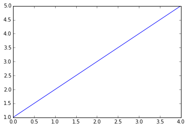

```python
plt.plot(wsdf.sales)
```

So we’re already learned something. The line plot is the default plot for Matplotlib, just as it is in native Pandas visualization. Nothing could be simpler. You’ll note that it’s not that easy to spot where the points are. We can fix that.

A consultation with the [documentation](http://matplotlib.org/api/pyplot_api.html#matplotlib.pyplot.boxplot) tells us that `plt.plot()` has certain arguments associated with it. Here are the more interesting.

`plt.plot(`

color= *a string or list*  
label= *a string with which to identify the data; see below*  
linestyle= *you can choose if a line is solid, dashed or other. Cf help(plt.plot)*  
linewidth= *an integer*  
marker= *as with the linestyle, there are different marker types to choose from*  
markeredgecolor= *a string with a recognisable color, a hex value, rgb, etc.*  
markeredgewidth= *an int*  
markerfacecolor= *as per markeredgecolor above*  
markersize= *an int. You can strike a balance between overplotting and dramatic effect, as we shall see soon*  
`)`

So here we can use the `color` attribute to make a thin red line

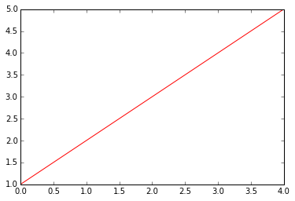

```python
plt.plot(wsdf.sales, color = 'red')
```

A thin red line with obvious marker points

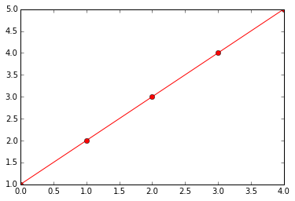

```python
plt.plot(wsdf.sales, color = 'red', marker = 'o')
```

Some markers on their own, thanks to some dexterous use of the `linewidth` argument.

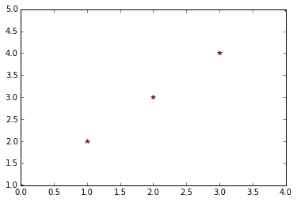

```python
plt.plot(wsdf.sales, color = 'red', marker = '*', linewidth = 0)
```

Sacrificing accuracy for impact with those points:

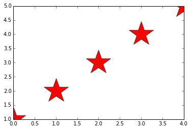

```python
plt.plot(wsdf.sales, color = 'red', marker = '*', markersize = 50, linewidth = 0)
```

#### Line v Scatter Plots

Scatter plots aren't difficult - relatively speaking - but they have quite a lot of depth. Unfortunately, to demonstate that depth would take up a lot of time and there's only so many charts we can look at tonight. Scatter plot fans shouldn't lose hope though - this is called Part 1, after all.

So, with that `plt.scatter()` absence noted, let's hit the bar.

### Bar Charts

`Plt.bar()` is the method for making bar charts in Matplotlib. You would think that plotting days against sales is the obvious way to make a bar chart of our sales data: `plt.bar(wsdf.days, wsdf.sales)`.

You would be wrong. Plotting days against sales throws up this frankly terrifying error message:

[output not shown]

Badly shaken, you go to the [documentation](http://matplotlib.org/api/pyplot_api.html?highlight=bar#matplotlib.pyplot.bar):

[figure not shown]

I can’t understand a word of that. Left? A sequence of scalars? All I want to know is where I put the days. What’s going on? Better try Google.

One of the highest-ranking results on Google is, naturally, a Stack Overflow page. It has a comment that I think is worth quoting as the ne plus ultra, there is no better, example of a Stack Overflow response:

> "To make a bar diagram with matplotlib, use the matplotlib.pyplot.bar() method. Have a look at this page of the matplotlib documentation that explains very well with examples and source code how to do it."

[figure not shown]

#### Bar Charts Take You Back to School

Making a Matplotlib bar chart takes you back to school. If you’re back in school doing this for homework, you draw your plot and then your bars and then write the categories at the bottom. In Matplotlib you do the same.

Consider this code: `plt.plot(range(4), range(4))`

Now, if you switch ‘bar’ for ‘plot,’ this is what happens:

```
<Container object of 4 artists>
```

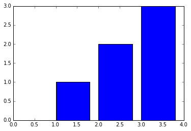

```python
plt.bar(range(4), range(4))
```

Remarkable. `range(4)` and `range(4)` were the scalars we were looking for – but what connects the to the data?

Matplotlib wants you to go back to school, and to do three things.

- Count out the number of bars.
- Associate values with the bars.
- Write in the bar labels.

So, the number of the bars is obviously `len(wsdf.days)`, and the values are `sdf.sales`. But wait – the docs asked for a range of scalars, so that’s what we’ll give them – `range(len(wsdf.days))`. Put all that into the oven and we get:

```
<Container object of 5 artists>
```

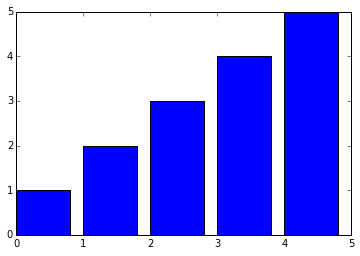

```python
plt.bar(range(len(wsdf.days)), wsdf.sales)
```

And there it is. We still don’t have the labels, but we can add them easily – well; relatively easily – enough, and we can also use the `plt.bar()` arguments to pretty the thing up a little:

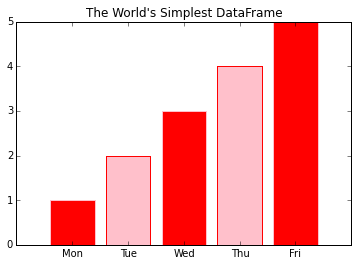

```python
plt.bar(np.arange(len(wsdf.days)), wsdf.sales,
        align = 'center',
        color = ['red', 'pink'],
        edgecolor = ['pink', 'red'])
plt.xticks(range(5), wsdf.days)
plt.title('The World\'s Simplest DataFrame')
```

#### Labelling

To just draw your attention to the `plt.xticks()` method for a moment. X-ticks are the markers along the x-axis of the graph. `plt.xticks()` takes two parameters - the number of bars, `range(5)` in our current case, and the labels for x-axis. But remember from the start that labels mean less than nothing to `plt.xticks()`, so we can write this without fear of reprecussion:

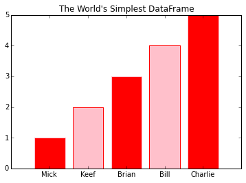

```python
rolling_stones = ["Mick", "Keef", "Brian", "Bill", "Charlie"]
plt.bar(np.arange(len(wsdf.days)), wsdf.sales,
        align = 'center',
        color = ['red', 'pink'],
        edgecolor = ['pink', 'red'])
plt.xticks(range(5), rolling_stones)
plt.title('The World\'s Simplest DataFrame')
```

And it'll work out just the same. Words only have semantic meaning to us. They're just some more ones and zeroes to the machine.

### The mtcars dataset

We’re going to have to leave our *World’s Simplest Data Frame* behind us now, as we need something a little more toothsome. Again, for familiarity, we’ll use the `mtcars` dataset that I’m sure everybody’s seen before. It’s a selection of cars as listed in a magazine called *Motor Trends* magazine in 1974, and these are its data types:

```python
mtcars = pd.read_csv('mtcars.csv')
print mtcars.dtypes
```

```
Unnamed: 0     object
mpg           float64
cyl             int64
disp          float64
hp              int64
drat          float64
wt            float64
qsec          float64
vs              int64
am              int64
gear            int64
carb            int64
dtype: object
```

### Histograms

MS Excel, for some reason, doesn't support histograms. I have no idea why. The native pandas plotting capability not only has histograms, but also does a very nice kernel density estimate graph too, like so:

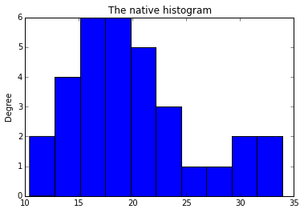

```python
mtcars.mpg.plot(kind = 'hist', title = 'The native histogram')
```

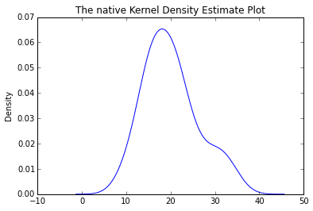

```python
mtcars.mpg.plot(kind = 'kde', title = 'The native Kernel Density Estimate Plot')
```

Sadly, `matplotlib.pyplot()` won't let you make a kernel density estimate graph unless you make a kernel density estimate first. We won't be going anywhere near such mind-bending maths tonight. We're going to keep it nice and simple with `pyplot.hist()`:

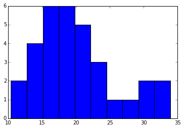

```python
plt.hist(mtcars.mpg)
```

#### Bins

The big thing about any histograms are its bins - that is to say, the number of divisions into which you wish to divide your data. There are two ways to do this:

1. Set the binwidth, as `ggplot()` does.
2. Decide on the total number of bins, as `plt.hist()` does. The default, as you can see above, is ten. The trick is to get it just right.

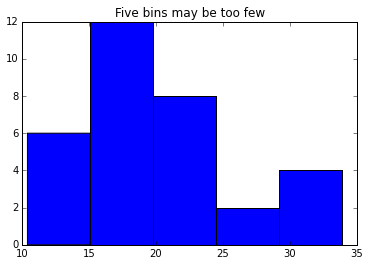

```python
plt.hist(mtcars.mpg, bins = 5)
plt.title("Five bins may be too few")
```

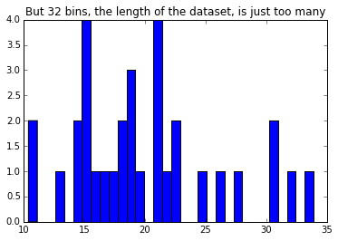

```python
plt.hist(mtcars.mpg, bins = 32)
plt.title("But 32 bins, the length of the dataset, is just too many")
```

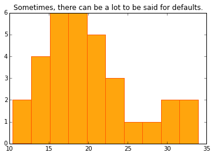

```python
plt.hist(mtcars.mpg, color = '#FFA50D', edgecolor = '#FF5C00')
plt.title("Sometimes, there can be a lot to be said for defaults.")
```

### Boxplots

The native Pandas plotting really comes into its own when it comes to boxplots. You want to know how miles per gallon breaks down against cylinder count? Nothing could be simpler:

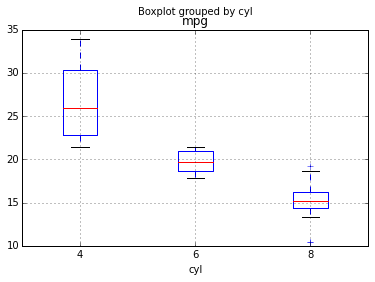

```python
mtcars.boxplot(column = 'mpg', by = 'cyl')
```

Isn't that beautiful? Instant information, at your fingertips.

In Matplotlib, making a boxplot is a little more gnarly, as people who were young once but might not be so young anymore might say.

This is the code outline:

[figure not shown]

Great. I want to know where my data goes and this thing is wittering on about notches and flier marks. However, like the oracle at Delphi, the Matplotlib documentation doesn’t leave us completely bereft. You’ll notice the reference to the “array or sequence of vectors.”

What the documention tells us that to make a Matplotlib boxplot, you’ll need your information in an array. If you’re information is in a data frame, you’re going to have to do some tramping through the rye. Specifically, you need to,

1. Create two lists, one for data and one for labels.
2. Break your category into groups (your category being what you would have written in the “by=” section for a native Pandas boxplot)
3. Iterate through your group, adding your sought-after data to the data list and your label (the group name) to the data list for each group.
4. Assemble your boxplot

Like so:

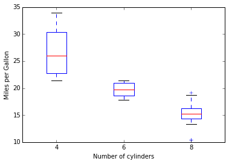

```python
# Step 1
myData = []
myLabels = []

# Step 2
cylinders = mtcars.groupby('cyl')

# Step 3
for a, b in cylinders:
    myData.append(b['mpg'])
    myLabels.append(a)

# Step 4
plt.boxplot(myData, labels = myLabels)
plt.xlabel("Number of cylinders")
plt.ylabel("Miles per Gallon")
```

## PLOTS, FIGURES AND AXES

We’ve noticed earlier that there is a certain inconsistency in Matplotlib methods and the language used to describe them. This reaches its apotheosis, I feel, when it comes to the concepts of plots, figures and axes. What is a plot? What is a figure? What is an axis/axes? How do they relate to each other?

#### More Inconsistencies

And as I say, it’s awkward. Technically, a figure is that thing on which our plots are drawn. But wait, you say – haven’t we been drawing plots all evening without ever mentioning figures? Yes, we have. This would be the inconsistency we’ve spoken of already, and we just have to live with it.

#### The Figure is Father to the Axes

The Luke-I-am-your-father thing is still to come, however. The figure on which we draw our plots can be broken down further, and these subsections, technically subplots, are called axes.

Now. The Oxford English dictionary has six definitions for axis as a concept, and none of them relate to the way the word is used in Matplotlib. As time goes by I think the use of the command `axes()` will recede as there are much handier ways of putting subplots together now. But in the meantime, you’re as well to accept that axes have rather specialized meanings in Matplotlib. It's not going to change anytime soon.

### Subplots

We talk about axes in the first place because they are necessary to generate subplots. Subplots are the pulled pork sandwiches of Matplotlib – once you discover them you can’t imagine life without them. In modern usage, subplots are created like so:

```
plt.subplots( nrows = <someInt>,
                ncols = <someInt>,
                sharex = <BOOL>,
                sharey = <BOOL>)
```

All self-explanatory, I think. Sharing the axes - or the axes of the axes, I should say :( - can be very useful in quickly noticing differences in data series.

#### Generating Subplots

You divide your figure into a grid of subplots, rows times columns, and you can decide whether or not you want the different x and y axes to be shared.

So that’s two objects that come into the world – the figure object, and it’s internal, axis object, that controls the subplots. The subplots are sensibly arranged in a grid, rows by columns, and this gives us the ability to fill them by co-ordinate.

Let's set up a figure, three rows by three columns, and let's then write to the middle axis. That sounds like a fun thing to do.

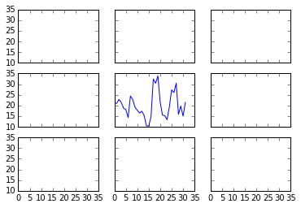

```python
fig, axes = plt.subplots(3,3, sharex = True, sharey = True)
axes[1,1].plot(mtcars.mpg)
```

Bull's-eye.

### It's Good to Share

Subplots come into their own when you can share axes - sometimes it's useful to have all your data on one chart, and other times it just makes for mess, like something Jackson Pollack threw out. So, to see just why all this is worth the bother, we'll try to create a chart with subplots that's a little more interesting.

#### Labels and Legends

`plt.plot()` has an argument called label. Label takes a string with which you can - obviously enough - label your data. If you then call the `plt.legend()` method, that will display your labels in the best way possible. Better together than bacon and eggs.

#### Creating a plot with subplots

1. First, group your data as you'd like them to appear
2. Store those data in a list for use later
3. Create a figure with eight suplots, arranged in four rows and two columns (in this case; x rows by y columns in other cases, of course)
4. Create an iterator for the list of data
5. Use for loops to iterate through the rows and the columns of the plot
6. Write to each axes as you go
7. Voila!

```python
# Group mtcars by cylinders and gears
groupData = mtcars.groupby(['cyl', 'gear'])

# Create a list to store the data which we'll use for the plots later
plottingData = []
for a, b in groupData:
    groupLabel = "{} cylinders\n{} gears".format(a[0], a[1])
    plottingData.append([groupLabel, b.wt, b.hp])
```

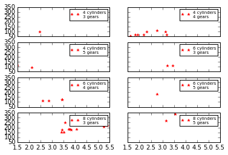

```python
# We'll create a figure that is 4 rows high by two columns wide
figure, axes = plt.subplots(4, 2, sharex = True, sharey = True)

i = 0 # our iterator for the plottingData list
for x in range(4):
    for y in range(2):
        axes[x,y].plot(plottingData[i][1],
                        plottingData[i][2],
                        color = 'r',
                        markeredgewidth = 0,
                        linewidth = 0,
                        marker = '*',
                        label = plottingData[i][0]) # The label argument mentioned earlier
        axes[x,y].legend(fontsize = 'x-small')      # and the legend() method.
        i += 1
```

#### The World's Most Pointless Graph

We had the *World's Simplest Data Frame* earlier. I think we can identify that last effort as the *World's Most Pointless Graph*, in real world terms. You can't make it out and, if you do, you learn nothing. But it does serve to illustrate a useful technique, so maybe it's not entirely pointless after all. I hope that this talk hasn't been entirely pointless either, and that even if you haven't learned anything new, you weren't bored senseless either.

#### Please Forgive Me, Documenters!

Before I go though, I should point out that although I've made a few cracks at the [Matplotlib documentation](http://matplotlib.org/index.html), I only did so to keep the tone light and keep people interested. Having done that, I’d be worse than a caveman if I didn’t make a point of noting that that the very fact those documents exist in the first place is a miracle and that if they didn’t we’d all be going around with candles in a hurricane. The people who wrote, collected and maintain those documents are the royalty in this endeavor and, for myself as a court jester, I can only beg them to understand I only teased because I knew they could take it.